# Advanced Data IO

## Google Sheets

[figure not shown]

https://docs.google.com/spreadsheets/d/1U6Cf_qEOhiR9AZqTqS3mbMF3zt2db48ZP5v3rkrAEJY/edit#gid=780868077

## Reading data with the googlesheets4 package

First, set up Google credentials.

```r
library(googlesheets4)
```

```r
# Prompts a browser pop-up
gs4_auth()
```

When prompted:

- “OK to cache OAuth access credentials in the folder between R sessions?”, select YES
- Make sure you select “allow” on your Google Account for the Tidyverse API.

## Reading data with the googlesheets4 package

```r
# Once set up, you can automate this process by passing your email
gs4_auth(email = "avamariehoffman@gmail.com")
```

## Reading data with the googlesheets4 package

You can also supply an authorization token directly, but make sure never to make these visible online!

```r
library(googledrive)
drive_auth(email= "<email>",
           token = readRDS("google-sheets-token.rds")) # Saved in a file
```

## Reading data with the googlesheets4 package

Read in using `read_sheet()`

```r
sheet_url <-
  "https://docs.google.com/spreadsheets/d/1U6Cf_qEOhiR9AZqTqS3mbMF3zt2db48ZP5v3rkrAEJY/edit#gid=780868077"
sheet_dat_1 <- read_sheet(sheet_url)
```

```
✔ Reading from "gapminder".
```

```
✔ Range 'Africa'.
```

```r
head(sheet_dat_1)
```

```
# A tibble: 6 × 6
  country continent  year lifeExp      pop gdpPercap
  <chr>   <chr>     <dbl>   <dbl>    <dbl>     <dbl>
1 Algeria Africa     1952    43.1  9279525     2449.
2 Algeria Africa     1957    45.7 10270856     3014.
3 Algeria Africa     1962    48.3 11000948     2551.
4 Algeria Africa     1967    51.4 12760499     3247.
5 Algeria Africa     1972    54.5 14760787     4183.
6 Algeria Africa     1977    58.0 17152804     4910.
```

## Reading data with the googlesheets4 package

Specify the sheet name if necessary:

```r
sheet_dat_oceania <- read_sheet(sheet_url, sheet = "Oceania")
```

```
✔ Reading from "gapminder".
```

```
✔ Range ''Oceania''.
```

```r
head(sheet_dat_oceania)
```

```
# A tibble: 6 × 6
  country   continent  year lifeExp      pop gdpPercap
  <chr>     <chr>     <dbl>   <dbl>    <dbl>     <dbl>
1 Australia Oceania    1952    69.1  8691212    10040.
2 Australia Oceania    1957    70.3  9712569    10950.
3 Australia Oceania    1962    70.9 10794968    12217.
4 Australia Oceania    1967    71.1 11872264    14526.
5 Australia Oceania    1972    71.9 13177000    16789.
6 Australia Oceania    1977    73.5 14074100    18334.
```

## Pull in a subset of data: rows

```r
read_sheet(sheet_url, sheet = "Oceania", range =  cell_rows(1:4))
```

```
✔ Reading from "gapminder".
```

```
✔ Range ''Oceania'!1:4'.
```

```
# A tibble: 3 × 6
  country   continent  year lifeExp      pop gdpPercap
  <chr>     <chr>     <dbl>   <dbl>    <dbl>     <dbl>
1 Australia Oceania    1952    69.1  8691212    10040.
2 Australia Oceania    1957    70.3  9712569    10950.
3 Australia Oceania    1962    70.9 10794968    12217.
```

## Pull in a subset of data: columns

```r
read_sheet(sheet_url, sheet = "Oceania", range =  cell_cols("A:B"))
```

```
✔ Reading from "gapminder".
```

```
✔ Range ''Oceania'!A:B'.
```

```
# A tibble: 24 × 2
   country   continent
   <chr>     <chr>
 1 Australia Oceania
 2 Australia Oceania
 3 Australia Oceania
 4 Australia Oceania
 5 Australia Oceania
 6 Australia Oceania
 7 Australia Oceania
 8 Australia Oceania
 9 Australia Oceania
10 Australia Oceania
# ℹ 14 more rows
```

## Reading data with the googlesheets4 package

List out the sheet names using `sheet_names()`.

```r
sheet_names(sheet_url)
```

```
[1] "Africa"   "Americas" "Asia"     "Europe"   "Oceania"
```

## Reading data with the googlesheets4 package

Iterate through the sheet names with `purrr`:

```r
gapminder_sheets <- sheet_names(sheet_url)

data_list <- map(gapminder_sheets, ~ read_sheet(sheet_url, sheet = .x))
```

```
✔ Reading from "gapminder".
```

```
✔ Range ''Africa''.
```

```
✔ Reading from "gapminder".
```

```
✔ Range ''Americas''.
```

```
✔ Reading from "gapminder".
```

```
✔ Range ''Asia''.
```

```
✔ Reading from "gapminder".
```

```
✔ Range ''Europe''.
```

```
✔ Reading from "gapminder".
```

```
✔ Range ''Oceania''.
```

## Reading data with the googlesheets4 package

Check out the list:

```r
str(data_list)
```

```
List of 5
 $ : tibble [624 × 6] (S3: tbl_df/tbl/data.frame)
  ..$ country  : chr [1:624] "Algeria" "Algeria" "Algeria" "Algeria" ...
  ..$ continent: chr [1:624] "Africa" "Africa" "Africa" "Africa" ...
  ..$ year     : num [1:624] 1952 1957 1962 1967 1972 ...
  ..$ lifeExp  : num [1:624] 43.1 45.7 48.3 51.4 54.5 ...
  ..$ pop      : num [1:624] 9279525 10270856 11000948 12760499 14760787 ...
  ..$ gdpPercap: num [1:624] 2449 3014 2551 3247 4183 ...
 $ : tibble [300 × 6] (S3: tbl_df/tbl/data.frame)
  ..$ country  : chr [1:300] "Argentina" "Argentina" "Argentina" "Argentina" ...
  ..$ continent: chr [1:300] "Americas" "Americas" "Americas" "Americas" ...
  ..$ year     : num [1:300] 1952 1957 1962 1967 1972 ...
  ..$ lifeExp  : num [1:300] 62.5 64.4 65.1 65.6 67.1 ...
  ..$ pop      : num [1:300] 17876956 19610538 21283783 22934225 24779799 ...
  ..$ gdpPercap: num [1:300] 5911 6857 7133 8053 9443 ...
 $ : tibble [396 × 6] (S3: tbl_df/tbl/data.frame)
  ..$ country  : chr [1:396] "Afghanistan" "Afghanistan" "Afghanistan" "Afghanistan" ...
  ..$ continent: chr [1:396] "Asia" "Asia" "Asia" "Asia" ...
  ..$ year     : num [1:396] 1952 1957 1962 1967 1972 ...
  ..$ lifeExp  : num [1:396] 28.8 30.3 32 34 36.1 ...
  ..$ pop      : num [1:396] 8425333 9240934 10267083 11537966 13079460 ...
  ..$ gdpPercap: num [1:396] 779 821 853 836 740 ...
 $ : tibble [360 × 6] (S3: tbl_df/tbl/data.frame)
  ..$ country  : chr [1:360] "Albania" "Albania" "Albania" "Albania" ...
  ..$ continent: chr [1:360] "Europe" "Europe" "Europe" "Europe" ...
  ..$ year     : num [1:360] 1952 1957 1962 1967 1972 ...
  ..$ lifeExp  : num [1:360] 55.2 59.3 64.8 66.2 67.7 ...
  ..$ pop      : num [1:360] 1282697 1476505 1728137 1984060 2263554 ...
  ..$ gdpPercap: num [1:360] 1601 1942 2313 2760 3313 ...
 $ : tibble [24 × 6] (S3: tbl_df/tbl/data.frame)
  ..$ country  : chr [1:24] "Australia" "Australia" "Australia" "Australia" ...
  ..$ continent: chr [1:24] "Oceania" "Oceania" "Oceania" "Oceania" ...
  ..$ year     : num [1:24] 1952 1957 1962 1967 1972 ...
  ..$ lifeExp  : num [1:24] 69.1 70.3 70.9 71.1 71.9 ...
  ..$ pop      : num [1:24] 8691212 9712569 10794968 11872264 13177000 ...
  ..$ gdpPercap: num [1:24] 10040 10950 12217 14526 16789 ...
```

## Reading data with the googlesheets4 package

Pull out sheets as needed:

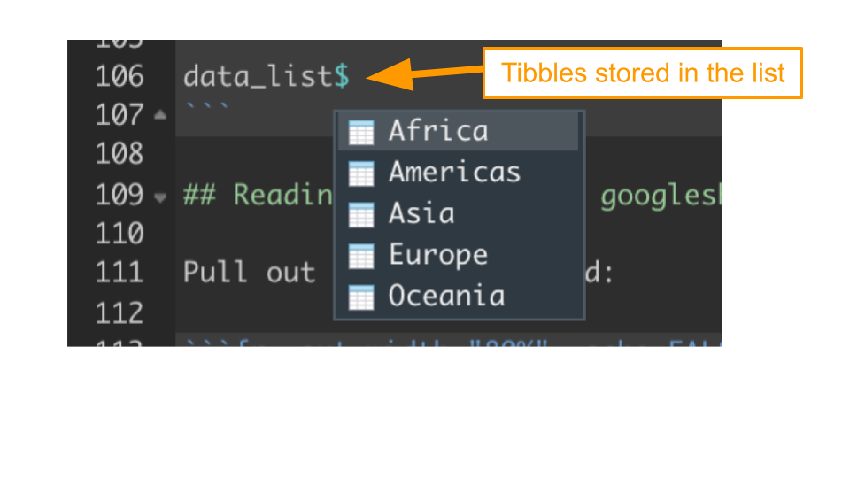

```r
data_list[[{sheet}]]
# OR
data_list %>% pluck({sheet})
# OR (if named)
data_list${sheet}
```

## Writing data with the googlesheets4 package

```r
sheet_dat_oceania <- data_list[[5]]

sheet_dat_oceania <- sheet_dat_oceania %>%
  mutate(lifeExp_days = lifeExp * 365)

sheet_out <- gs4_create("Oceania-days",
                       sheets = list(Oceania_days = sheet_dat_oceania))
```

```
✔ Creating new Sheet: "Oceania-days".
```

```r
# Opens a browser window
gs4_browse(sheet_out)
```

## Append data with the googlesheets4 package

```r
sheet_append(sheet_out, data = sheet_dat_oceania, sheet = "Oceania_days")
```

```
✔ Writing to "Oceania-days".
```

```
✔ Appending 24 rows to 'Oceania_days'.
```

## JHU Tidyverse Book

https://jhudatascience.org/tidyversecourse/get-data.html#google-sheets

## Lab

http://sisbid.github.io/Data-Wrangling/labs/advanced-io-lab.Rmd

## JSON: JavaScript Object Notation Lists of stuff

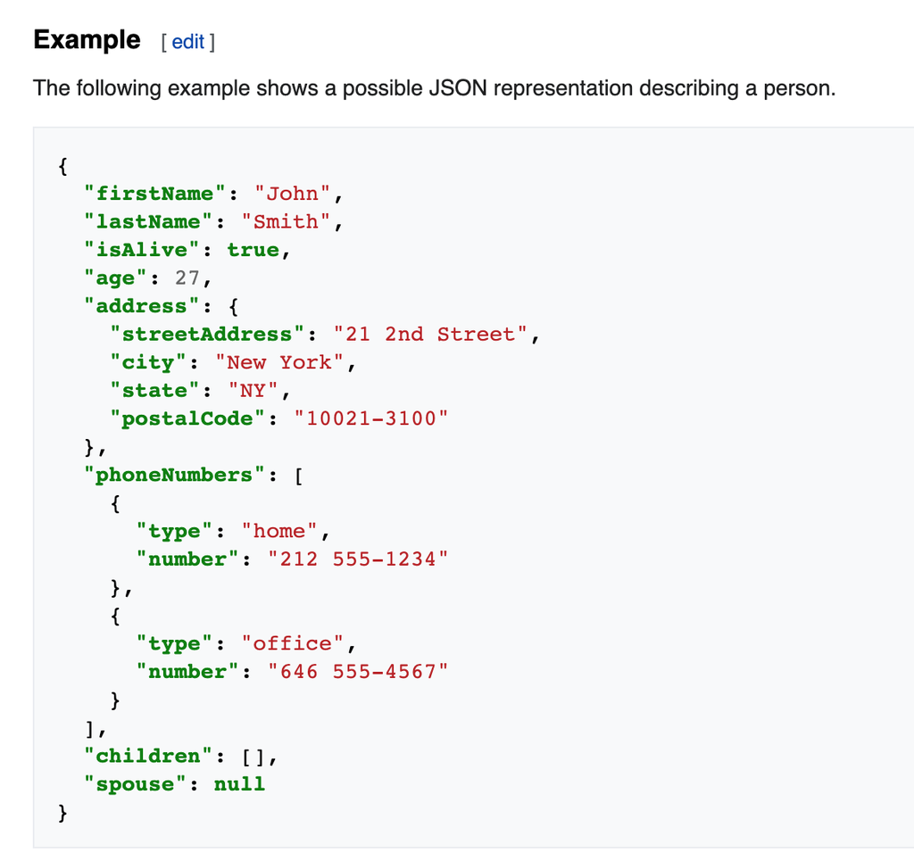

https://en.wikipedia.org/wiki/JSON

## Why JSON matters

[figure not shown]

https://docs.github.com/en/rest/reference/search

```r
#install.packages("jsonlite")
library(jsonlite)
jsonData <-
  fromJSON("https://raw.githubusercontent.com/Biuni/PokemonGO-Pokedex/master/pokedex.json")
head(jsonData)
```

[output not shown]

[output not shown]

[output not shown]

[output not shown]

[output not shown]

## Data frame structure from JSON

```r
dim(jsonData$pokemon)
```

```
[1] 151  17
```

```r
class(jsonData$pokemon)
```

```
[1] "data.frame"
```

```r
jsonData$pokemon %>% filter(type == "Fire") %>% select(!(img))
```

```
    id num       name type height   weight            candy candy_count
1    4 004 Charmander Fire 0.61 m   8.5 kg Charmander Candy          25
2    5 005 Charmeleon Fire 1.09 m  19.0 kg Charmander Candy         100
3   37 037     Vulpix Fire 0.61 m   9.9 kg     Vulpix Candy          50
4   38 038  Ninetales Fire 1.09 m  19.9 kg     Vulpix Candy          NA
5   58 058  Growlithe Fire 0.71 m  19.0 kg  Growlithe Candy          50
6   59 059   Arcanine Fire 1.91 m 155.0 kg  Growlithe Candy          NA
7   77 077     Ponyta Fire 0.99 m  30.0 kg     Ponyta Candy          50
8   78 078   Rapidash Fire 1.70 m  95.0 kg     Ponyta Candy          NA
9  126 126     Magmar Fire 1.30 m  44.5 kg             None          NA
10 136 136    Flareon Fire 0.89 m  25.0 kg      Eevee Candy          NA
           egg spawn_chance avg_spawns spawn_time multipliers
1         2 km       0.2530      25.30      08:45        1.65
2  Not in Eggs       0.0120       1.20      19:00        1.79
3         5 km       0.2200      22.00      13:43  2.74, 2.81
4  Not in Eggs       0.0077       0.77      01:32        NULL
5         5 km       0.9200      92.00      03:57  2.31, 2.36
6  Not in Eggs       0.0170       1.70      03:11        NULL
7         5 km       0.5100      51.00      02:50  1.48, 1.50
8  Not in Eggs       0.0110       1.10      04:00        NULL
9        10 km       0.1000      10.00      20:36        NULL
10 Not in Eggs       0.0170       1.70      07:02        NULL
            weaknesses                  next_evolution  prev_evolution
1  Water, Ground, Rock 005, 006, Charmeleon, Charizard            NULL
2  Water, Ground, Rock                  006, Charizard 004, Charmander
3  Water, Ground, Rock                  038, Ninetales            NULL
4  Water, Ground, Rock                            NULL     037, Vulpix
5  Water, Ground, Rock                   059, Arcanine            NULL
6  Water, Ground, Rock                            NULL  058, Growlithe
7  Water, Ground, Rock                   078, Rapidash            NULL
8  Water, Ground, Rock                            NULL     077, Ponyta
9  Water, Ground, Rock                            NULL            NULL
10 Water, Ground, Rock                            NULL      133, Eevee
```

## Going deeper..

```r
class(jsonData$pokemon$type) # Can be lists
```

```
[1] "list"
```

```r
jsonData$pokemon$type
```

```
[[1]]
[1] "Grass"  "Poison"

[[2]]
[1] "Grass"  "Poison"

[[3]]
[1] "Grass"  "Poison"

[[4]]
[1] "Fire"

[[5]]
[1] "Fire"

[[6]]
[1] "Fire"   "Flying"

[[7]]
[1] "Water"

[[8]]
[1] "Water"

[[9]]
[1] "Water"

[[10]]
[1] "Bug"

[[11]]
[1] "Bug"

[[12]]
[1] "Bug"    "Flying"

[[13]]
[1] "Bug"    "Poison"

[[14]]
[1] "Bug"    "Poison"

[[15]]
[1] "Bug"    "Poison"

[[16]]
[1] "Normal" "Flying"

[[17]]
[1] "Normal" "Flying"

[[18]]
[1] "Normal" "Flying"

[[19]]
[1] "Normal"

[[20]]
[1] "Normal"

[[21]]
[1] "Normal" "Flying"

[[22]]
[1] "Normal" "Flying"

[[23]]
[1] "Poison"

[[24]]
[1] "Poison"

[[25]]
[1] "Electric"

[[26]]
[1] "Electric"

[[27]]
[1] "Ground"

[[28]]
[1] "Ground"

[[29]]
[1] "Poison"

[[30]]
[1] "Poison"

[[31]]
[1] "Poison" "Ground"

[[32]]
[1] "Poison"

[[33]]
[1] "Poison"

[[34]]
[1] "Poison" "Ground"

[[35]]
[1] "Normal"

[[36]]
[1] "Normal"

[[37]]
[1] "Fire"

[[38]]
[1] "Fire"

[[39]]
[1] "Normal"

[[40]]
[1] "Normal"

[[41]]
[1] "Poison" "Flying"

[[42]]
[1] "Poison" "Flying"

[[43]]
[1] "Grass"  "Poison"

[[44]]
[1] "Grass"  "Poison"

[[45]]
[1] "Grass"  "Poison"

[[46]]
[1] "Bug"   "Grass"

[[47]]
[1] "Bug"   "Grass"

[[48]]
[1] "Bug"    "Poison"

[[49]]
[1] "Bug"    "Poison"

[[50]]
[1] "Ground"

[[51]]
[1] "Ground"

[[52]]
[1] "Normal"

[[53]]
[1] "Normal"

[[54]]
[1] "Water"

[[55]]
[1] "Water"

[[56]]
[1] "Fighting"

[[57]]
[1] "Fighting"

[[58]]
[1] "Fire"

[[59]]
[1] "Fire"

[[60]]
[1] "Water"

[[61]]
[1] "Water"

[[62]]
[1] "Water"    "Fighting"

[[63]]
[1] "Psychic"

[[64]]
[1] "Psychic"

[[65]]
[1] "Psychic"

[[66]]
[1] "Fighting"

[[67]]
[1] "Fighting"

[[68]]
[1] "Fighting"

[[69]]
[1] "Grass"  "Poison"

[[70]]
[1] "Grass"  "Poison"

[[71]]
[1] "Grass"  "Poison"

[[72]]
[1] "Water"  "Poison"

[[73]]
[1] "Water"  "Poison"

[[74]]
[1] "Rock"   "Ground"

[[75]]
[1] "Rock"   "Ground"

[[76]]
[1] "Rock"   "Ground"

[[77]]
[1] "Fire"

[[78]]
[1] "Fire"

[[79]]
[1] "Water"   "Psychic"

[[80]]
[1] "Water"   "Psychic"

[[81]]
[1] "Electric"

[[82]]
[1] "Electric"

[[83]]
[1] "Normal" "Flying"

[[84]]
[1] "Normal" "Flying"

[[85]]
[1] "Normal" "Flying"

[[86]]
[1] "Water"

[[87]]
[1] "Water" "Ice"

[[88]]
[1] "Poison"

[[89]]
[1] "Poison"

[[90]]
[1] "Water"

[[91]]
[1] "Water" "Ice"

[[92]]
[1] "Ghost"  "Poison"

[[93]]
[1] "Ghost"  "Poison"

[[94]]
[1] "Ghost"  "Poison"

[[95]]
[1] "Rock"   "Ground"

[[96]]
[1] "Psychic"

[[97]]
[1] "Psychic"

[[98]]
[1] "Water"

[[99]]
[1] "Water"

[[100]]
[1] "Electric"

[[101]]
[1] "Electric"

[[102]]
[1] "Grass"   "Psychic"

[[103]]
[1] "Grass"   "Psychic"

[[104]]
[1] "Ground"

[[105]]
[1] "Ground"

[[106]]
[1] "Fighting"

[[107]]
[1] "Fighting"

[[108]]
[1] "Normal"

[[109]]
[1] "Poison"

[[110]]
[1] "Poison"

[[111]]
[1] "Ground" "Rock"

[[112]]
[1] "Ground" "Rock"

[[113]]
[1] "Normal"

[[114]]
[1] "Grass"

[[115]]
[1] "Normal"

[[116]]
[1] "Water"

[[117]]
[1] "Water"

[[118]]
[1] "Water"

[[119]]
[1] "Water"

[[120]]
[1] "Water"

[[121]]
[1] "Water"   "Psychic"

[[122]]
[1] "Psychic"

[[123]]
[1] "Bug"    "Flying"

[[124]]
[1] "Ice"     "Psychic"

[[125]]
[1] "Electric"

[[126]]
[1] "Fire"

[[127]]
[1] "Bug"

[[128]]
[1] "Normal"

[[129]]
[1] "Water"

[[130]]
[1] "Water"  "Flying"

[[131]]
[1] "Water" "Ice"

[[132]]
[1] "Normal"

[[133]]
[1] "Normal"

[[134]]
[1] "Water"

[[135]]
[1] "Electric"

[[136]]
[1] "Fire"

[[137]]
[1] "Normal"

[[138]]
[1] "Rock"  "Water"

[[139]]
[1] "Rock"  "Water"

[[140]]
[1] "Rock"  "Water"

[[141]]
[1] "Rock"  "Water"

[[142]]
[1] "Rock"   "Flying"

[[143]]
[1] "Normal"

[[144]]
[1] "Ice"    "Flying"

[[145]]
[1] "Electric" "Flying"

[[146]]
[1] "Fire"   "Flying"

[[147]]
[1] "Dragon"

[[148]]
[1] "Dragon"

[[149]]
[1] "Dragon" "Flying"

[[150]]
[1] "Psychic"

[[151]]
[1] "Psychic"
```

## Data frame structure from JSON

```r
class(jsonData$pokemon$next_evolution[[1]]) # Or lists of data.frames!
```

```
[1] "data.frame"
```

```r
jsonData$pokemon$next_evolution
```

```
[[1]]
  num     name
1 002  Ivysaur
2 003 Venusaur

[[2]]
  num     name
1 003 Venusaur

[[3]]
NULL

[[4]]
  num       name
1 005 Charmeleon
2 006  Charizard

[[5]]
  num      name
1 006 Charizard

[[6]]
NULL

[[7]]
  num      name
1 008 Wartortle
2 009 Blastoise

[[8]]
  num      name
1 009 Blastoise

[[9]]
NULL

[[10]]
  num       name
1 011    Metapod
2 012 Butterfree

[[11]]
  num       name
1 012 Butterfree

[[12]]
NULL

[[13]]
  num     name
1 014   Kakuna
2 015 Beedrill

[[14]]
  num     name
1 015 Beedrill

[[15]]
NULL

[[16]]
  num      name
1 017 Pidgeotto
2 018   Pidgeot

[[17]]
  num    name
1 018 Pidgeot

[[18]]
NULL

[[19]]
  num     name
1 020 Raticate

[[20]]
NULL

[[21]]
  num   name
1 022 Fearow

[[22]]
NULL

[[23]]
  num  name
1 024 Arbok

[[24]]
NULL

[[25]]
  num   name
1 026 Raichu

[[26]]
NULL

[[27]]
  num      name
1 028 Sandslash

[[28]]
NULL

[[29]]
  num      name
1 030  Nidorina
2 031 Nidoqueen

[[30]]
  num      name
1 031 Nidoqueen

[[31]]
NULL

[[32]]
  num     name
1 033 Nidorino
2 034 Nidoking

[[33]]
  num     name
1 034 Nidoking

[[34]]
NULL

[[35]]
  num     name
1 036 Clefable

[[36]]
NULL

[[37]]
  num      name
1 038 Ninetales

[[38]]
NULL

[[39]]
  num       name
1 040 Wigglytuff

[[40]]
NULL

[[41]]
  num   name
1 042 Golbat

[[42]]
NULL

[[43]]
  num      name
1 044     Gloom
2 045 Vileplume

[[44]]
  num      name
1 045 Vileplume

[[45]]
NULL

[[46]]
  num     name
1 047 Parasect

[[47]]
NULL

[[48]]
  num     name
1 049 Venomoth

[[49]]
NULL

[[50]]
  num    name
1 051 Dugtrio

[[51]]
NULL

[[52]]
  num    name
1 053 Persian

[[53]]
NULL

[[54]]
  num    name
1 055 Golduck

[[55]]
NULL

[[56]]
  num     name
1 057 Primeape

[[57]]
NULL

[[58]]
  num     name
1 059 Arcanine

[[59]]
NULL

[[60]]
  num      name
1 061 Poliwhirl
2 062 Poliwrath

[[61]]
  num      name
1 062 Poliwrath

[[62]]
NULL

[[63]]
  num     name
1 064  Kadabra
2 065 Alakazam

[[64]]
  num     name
1 065 Alakazam

[[65]]
NULL

[[66]]
  num    name
1 067 Machoke
2 068 Machamp

[[67]]
  num    name
1 068 Machamp

[[68]]
NULL

[[69]]
  num       name
1 070 Weepinbell
2 071 Victreebel

[[70]]
  num       name
1 071 Victreebel

[[71]]
NULL

[[72]]
  num       name
1 073 Tentacruel

[[73]]
NULL

[[74]]
  num     name
1 075 Graveler
2 076    Golem

[[75]]
  num  name
1 076 Golem

[[76]]
NULL

[[77]]
  num     name
1 078 Rapidash

[[78]]
NULL

[[79]]
  num    name
1 080 Slowbro

[[80]]
NULL

[[81]]
  num     name
1 082 Magneton

[[82]]
NULL

[[83]]
NULL

[[84]]
  num   name
1 085 Dodrio

[[85]]
NULL

[[86]]
  num    name
1 087 Dewgong

[[87]]
NULL

[[88]]
  num name
1 089  Muk

[[89]]
NULL

[[90]]
  num     name
1 091 Cloyster

[[91]]
NULL

[[92]]
  num    name
1 093 Haunter
2 094  Gengar

[[93]]
  num   name
1 094 Gengar

[[94]]
NULL

[[95]]
NULL

[[96]]
  num  name
1 097 Hypno

[[97]]
NULL

[[98]]
  num    name
1 099 Kingler

[[99]]
NULL

[[100]]
  num      name
1 101 Electrode

[[101]]
NULL

[[102]]
  num      name
1 103 Exeggutor

[[103]]
NULL

[[104]]
  num    name
1 105 Marowak

[[105]]
NULL

[[106]]
NULL

[[107]]
NULL

[[108]]
NULL

[[109]]
  num    name
1 110 Weezing

[[110]]
NULL

[[111]]
  num   name
1 112 Rhydon

[[112]]
NULL

[[113]]
NULL

[[114]]
NULL

[[115]]
NULL

[[116]]
  num   name
1 117 Seadra

[[117]]
NULL

[[118]]
  num    name
1 119 Seaking

[[119]]
NULL

[[120]]
  num    name
1 121 Starmie

[[121]]
NULL

[[122]]
NULL

[[123]]
NULL

[[124]]
NULL

[[125]]
NULL

[[126]]
NULL

[[127]]
NULL

[[128]]
NULL

[[129]]
  num     name
1 130 Gyarados

[[130]]
NULL

[[131]]
NULL

[[132]]
NULL

[[133]]
  num     name
1 134 Vaporeon
2 135  Jolteon
3 136  Flareon

[[134]]
NULL

[[135]]
NULL

[[136]]
NULL

[[137]]
NULL

[[138]]
  num    name
1 139 Omastar

[[139]]
NULL

[[140]]
  num     name
1 141 Kabutops

[[141]]
NULL

[[142]]
NULL

[[143]]
NULL

[[144]]
NULL

[[145]]
NULL

[[146]]
NULL

[[147]]
  num      name
1 148 Dragonair
2 149 Dragonite

[[148]]
  num      name
1 149 Dragonite

[[149]]
NULL

[[150]]
NULL

[[151]]
NULL
```

## Summary

- `googlesheets4`: interface with Google Sheets
  - use `gs4_auth()` to stash and set up credentials
  - use `read_sheet()` and other functions to bring data in
- `jsonlite`: make sense of .json data
  - use `$` notation to explore structure

http://sisbid.github.io/Data-Wrangling/labs/advanced-io-lab.Rmd

## Extra Slides: Web Scraping and APIs

## This is data

http://bowtie-bio.sourceforge.net/recount/

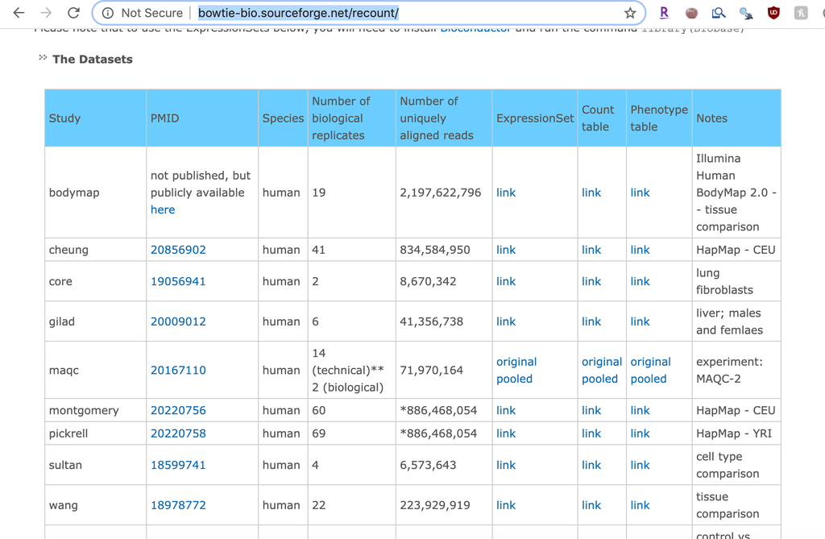

## View the source

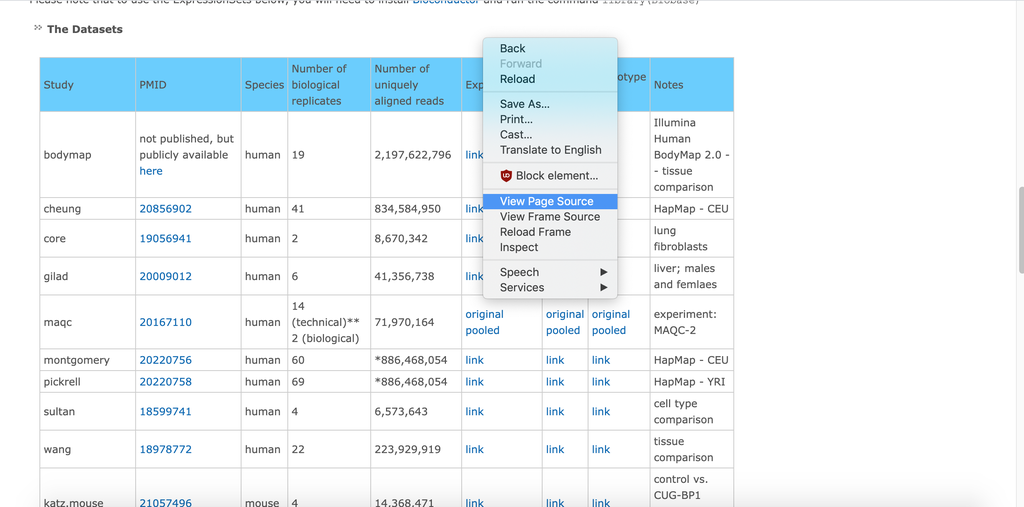

## What the computer sees

[figure not shown]

## Ways to see the source

Chrome:

1. right click on page
2. select “View Page Source”

Firefox:

1. right click on page
2. select “View Page Source”

Microsoft Edge:

1. right click on page
2. select “view source”

Safari

1. click on “Safari”
2. select “Preferences”
3. go to “Advanced”
4. check “Show Develop menu in menu bar”
5. right click on page
6. select “View Page Source”

https://github.com/simonmunzert/rscraping-jsm-2016/blob/c04fd91fec711df65c838e07723125155a7f2cda/02-scraping-with-rvest.r

## Inspect element

[figure not shown]

## Copy XPath

[figure not shown]

## Use SelectorGadget

https://rvest.tidyverse.org/articles/selectorgadget.html

## rvest package

```r
recount_url <- "http://bowtie-bio.sourceforge.net/recount/"
# install.packages("rvest")
library(rvest)
htmlfile <- read_html(recount_url)

nds <- html_nodes(htmlfile, xpath = '//*[@id="recounttab"]/table')
dat <- html_table(nds)
dat <- as.data.frame(dat)
head(dat)
```

```
       X1                                         X2      X3
1   Study                                       PMID Species
2 bodymap not published, but publicly available here   human
3  cheung                                   20856902   human
4    core                                   19056941   human
5   gilad                                   20009012   human
6    maqc                                   20167110   human
                                X4                               X5
1  Number of biological replicates Number of uniquely aligned reads
2                               19                    2,197,622,796
3                               41                      834,584,950
4                                2                        8,670,342
5                                6                       41,356,738
6 14 (technical)**  2 (biological)                       71,970,164
               X6              X7              X8
1   ExpressionSet     Count table Phenotype table
2            link            link            link
3            link            link            link
4            link            link            link
5            link            link            link
6 original pooled original pooled original pooled
                                               X9
1                                           Notes
2 Illumina Human BodyMap 2.0 -- tissue comparison
3                                    HapMap - CEU
4                                lung fibroblasts
5                        liver; males and femlaes
6                              experiment: MAQC-2
```

## Little cleanup

```r
colnames(dat) <- as.character(dat[1,])
dat <- dat[-1,]
head(dat)
```

```
       Study                                       PMID Species
2    bodymap not published, but publicly available here   human
3     cheung                                   20856902   human
4       core                                   19056941   human
5      gilad                                   20009012   human
6       maqc                                   20167110   human
7 montgomery                                   20220756   human
   Number of biological replicates Number of uniquely aligned reads
2                               19                    2,197,622,796
3                               41                      834,584,950
4                                2                        8,670,342
5                                6                       41,356,738
6 14 (technical)**  2 (biological)                       71,970,164
7                               60                     *886,468,054
    ExpressionSet     Count table Phenotype table
2            link            link            link
3            link            link            link
4            link            link            link
5            link            link            link
6 original pooled original pooled original pooled
7            link            link            link
                                            Notes
2 Illumina Human BodyMap 2.0 -- tissue comparison
3                                    HapMap - CEU
4                                lung fibroblasts
5                        liver; males and femlaes
6                              experiment: MAQC-2
7                                    HapMap - CEU
```

## Ethics and Web Scraping

https://slate.com/culture/2020/04/whitney-museum-new-york-apartment-exhibit-creators-interview.html

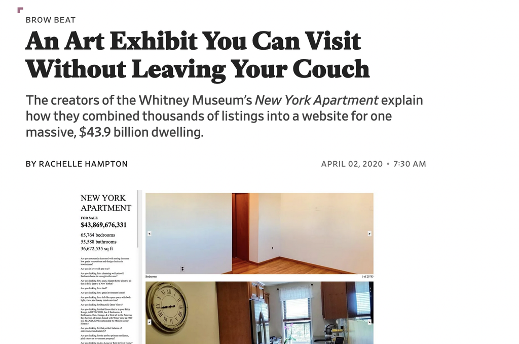

## Ethics and Web Scraping

https://doi.org/10.1016/j.dib.2020.106178

[figure not shown]

## Ethics and Web Scraping

https://techcrunch.com/2017/04/28/someone-scraped-40000-tinder-selfies-to-make-a-facial-dataset-for-ai-experiments/

[figure not shown]

## Ethics and Web Scraping

https://on.wsj.com/3hzeu9i

[figure not shown]

## APIs

## Application Programming Interfaces

https://developers.facebook.com/

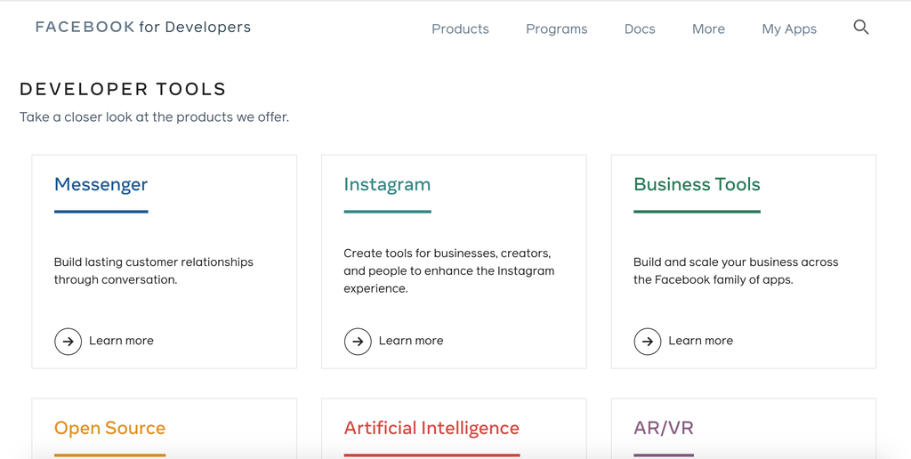

## In biology too!

http://www.ncbi.nlm.nih.gov/books/NBK25501/ https://www.ncbi.nlm.nih.gov/home/develop/api/

[figure not shown]

## Step 0: Did someone do this already

https://ropensci.org/packages/

[figure not shown]

## Step 0: Did someone do this already

`tidycensus` package: https://walker-data.com/tidycensus/articles/basic-usage.html

[figure not shown]

## Step 1: DIY

https://github.com/ThatCopy/catAPI/wiki/Usage

```r
#install.packages("httr")
library(httr)

# Requests a random cat fact
query_url <- "https://catfact.ninja/fact"

req <- GET(query_url)
content(req)
```

```
$fact
[1] "Milk can give some cats diarrhea."

$length
[1] 33
```

## Not all APIs are “open”

https://walker-data.com/tidycensus/articles/basic-usage.html

```r
# install.packages("tidycensus")
library(tidycensus)
# Supplied by census.gov
census_api_key("YOUR API KEY GOES HERE")

get_decennial(geography = "state",
                       variables = "P013001", # code for median age
                       year = 2010)
```